# A Simulated Data Example: Addressing Numerical Instability in $\beta\text{ARMA}$ Models

Reproducing the CMLE and PCMLE from Cribari-Neto, Costa, & Fonseca (2025)

Everton da Costa

2025-10-07

# Example with simulated time series

## Introduction

This vignette reproduces a key simulation study from Cribari-Neto, Costa, & Fonseca (2025). We demonstrate a common numerical instability issue that arises when fitting beta autoregressive moving average ($\beta\text{ARMA}$) models. Specifically, we will fit a $\beta\text{ARMA(1,4)}$ model to data generated from a $\beta\text{AR(1)}$ process. This example corresponds to the results shown in Table 1 (unpenalized estimation) and Table 3 (penalized estimation) of the paper. We first show how standard optimization methods can fail to converge or produce implausible estimates and then demonstrate how the proposed ridge penalization provides a more stable and accurate solution.

**Key Reference:** Cribari-Neto, F., Costa, E., & Fonseca, R. V. (2025). Numerical stability enhancements in beta autoregressive moving average model estimation.

## Simulated Data and Model Setup

We begin by loading the R packages required for this simulation, including tools for time series analysis (`forecast`), data handling (`dplyr`), and plotting (`ggplot2`).

```r
library(BarmaRidgeBJPS2025)
library(forecast) # time series
library(ggplot2) # plotting
library(dplyr) # data manipulation
```

### Functions

To demonstrate the package’s internal mechanics for this vignette, we access several non-exported functions using the `:::` operator. This makes them easier to call and inspect in the following examples.

```r
# -----------------------------------------------------------------------------
# Core functions for the standard ARMA model
# -----------------------------------------------------------------------------
start_values <- BarmaRidgeBJPS2025:::start_values
loglik_arma <- BarmaRidgeBJPS2025:::loglik_arma
score_vector_arma <- BarmaRidgeBJPS2025:::score_vector_arma
inf_matrix_arma <- BarmaRidgeBJPS2025:::inf_matrix_arma

# -----------------------------------------------------------------------------
# Corresponding functions for the ridge-penalized (L2) model
# -----------------------------------------------------------------------------
loglik_arma_ridge <- BarmaRidgeBJPS2025:::loglik_arma_ridge
score_vector_arma_ridge <- BarmaRidgeBJPS2025:::score_vector_arma_ridge

# -----------------------------------------------------------------------------
# Utility function for creating link structures
# -----------------------------------------------------------------------------
make_link_structure <- BarmaRidgeBJPS2025:::make_link_structure
```

### Specification

This chunk configures all parameters for our simulation. We define the model structure (link function, $\beta\text{ARMA}$ order) and the true parameter values used to generate the synthetic time series data.

```r
# --------------------------------------------------------------------------- #
# 1. Link Function Setup
# --------------------------------------------------------------------------- #
# We'll use a logit link for the conditional mean of the beta distribution.
link <- "logit"
link_structure <- make_link_structure(link)

# Extract the link function, its inverse, and the derivative of the inverse.
linkfun <- link_structure$linkfun
linkinv <- link_structure$linkinv
mu.eta <- link_structure$mu.eta

# --------------------------------------------------------------------------- #
# 2. Model Specification
# --------------------------------------------------------------------------- #
# Define the ARMA(p, q) order for the model we intend to fit.
ar_vec <- 1 # p = 1
ma_vec <- 1:4 # q = 4

# --------------------------------------------------------------------------- #
# 3. Data Generation Parameters
# --------------------------------------------------------------------------- #
# Set a seed for reproducibility of the data simulation.
seed <- 34

# Define the sample sizes.
n <- 250 # Final sample size after burn-in
burn <- 1000 # Observations to discard (burn-in period)
nburn <- n + burn # Total observations to generate

# Set the true parameter values for the data generating process.
# Note: The true model is a BARMA(1,0), which will be fitted using BARMA(1,4)
# model.
varphi_true <- 0.4 # AR(1) coefficient
theta_true <- NA # No MA terms in the true model
alpha_true <- 0 # Intercept for the linear predictor
phi_true <- 20 # Precision parameter for the Beta distribution
```

### Time Series

The initial `burn` observations are discarded as a burn-in period. This helps mitigate the influence of initial conditions and ensures the simulated series has reached its stationary distribution.

```r
# Set the seed to ensure the data simulation is reproducible.
set.seed(seed)

# Simulate a BARMA time series using the true parameters defined previously.
y_burn <- simu_barma(
  n = nburn,
  varphi = varphi_true,
  theta = theta_true,
  alpha = alpha_true,
  phi = phi_true
)

# Discard the burn-in period and create the final time series object.
# We assume monthly data, so we set the frequency to 12.
final_indices <- (burn + 1):nburn
y <- ts(y_burn[final_indices], frequency = 12)
```

Time series plot

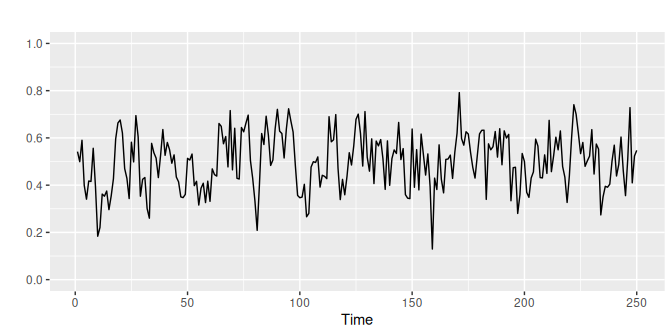

```r
# First, convert the time series object into a tibble for plotting.
df <- tibble(time = 1:length(y), value = y)

# Now, create the line plot of the simulated data.
ggplot(df, aes(x = time, y = value)) +
  geom_line() +
  labs(
    x = "Time",
    y = "",
    title = " "
  ) +
  scale_y_continuous(limits = c(0, 1), breaks = seq(0, 1, 0.20))
```

### Start values

Before running the optimization, we need to generate initial parameter estimates. The `start_values()` helper function provides starting points based on the time series data, which helps the optimization algorithm converge more efficiently.

```r
# Obtain initial parameter estimates using the package's helper function.
start_par <- start_values(y = y, ar = ar_vec, ma = ma_vec, link = link)

# Display the starting values in a formatted table.
start_par_print <- round(start_par, 4)
start_par_print <- t(as.data.frame(start_par_print))
rownames(start_par_print) <- NULL
```

Initial parameter estimates for the BARMA(1,4) model.

| alpha | varphi1 | theta1 | theta2 | theta3 | theta4 | phi |
| --- | --- | --- | --- | --- | --- | --- |
| -0.0045 | 0.4504 | 0 | 0 | 0 | 0 | 19.8918 |

### Estimation

Before proceeding to the optimization, we define several key parameters for the estimation procedure. This includes the model order (`p` and `q`), the sample size (`n`), and the penalty term ($\lambda$) for the ridge regression.

```r
# --------------------------------------------------------------------------- #
# Define key parameters for the estimation procedure
# --------------------------------------------------------------------------- #
# Determine the maximum AR and MA lags.
p_max <- max(ar_vec)
q_max <- max(ma_vec)

# Get the number of AR (p) and MA (q) parameters to be estimated.
p_len <- length(ar_vec)
q_len <- length(ma_vec)

# Get the length of the time series.
n <- length(y)

# --------------------------------------------------------------------------- #
# Define the penalty term for the ridge regression
# --------------------------------------------------------------------------- #
# This penalty term will be used later for the penalized estimation.
# The formula provides a small shrinkage value that depends on sample size.
a_max <- max(ar_vec, ma_vec)
penalty <- 1 / (n - a_max)^(0.90)
```

## Optimization

### Conditional Maximum Likelihood Estimation

Demonstrating Numerical Instability

First, we’ll attempt to fit the model using the standard Conditional Maximum Likelihood Estimation (CMLE). The following chunk uses the `stats::optim` function with the `BFGS` algorithm. As demonstrated in the paper, this standard approach can fail to converge for certain time series, which is what we expect to see here.

```r
# --------------------------------------------------------------------------- #
# Perform Conditional Maximum Likelihood Estimation (CMLE) via `stats::optim()`
# --------------------------------------------------------------------------- #
optim_AG_BFGS <- stats::optim(
  par = start_par,

  # The objective function (fn) is the negative log-likelihood.
  fn = function(estimate) {
    (-1) * loglik_arma(
      y = y,
      ar = ar_vec,
      ma = ma_vec,
      alpha = estimate[1],
      varphi = estimate[2:(p_len + 1)],
      theta = estimate[(p_len + 2):(p_len + q_len + 1)],
      phi = estimate[p_len + q_len + 2],
      link = link
    )
  },

  # The gradient (gr) is the negative score vector (the first derivative
  # of the log-likelihood).
  gr = function(estimate) {
    (-1) * score_vector_arma(
      y = y,
      ar = ar_vec,
      ma = ma_vec,
      alpha = estimate[1],
      varphi = estimate[2:(p_len + 1)],
      theta = estimate[(p_len + 2):(p_len + q_len + 1)],
      phi = estimate[p_len + q_len + 2],
      link = link
    )
  },
  method = "BFGS"
)

# Display the final parameter estimates in a formatted table.
optim_AG_BFGS_par <- round(optim_AG_BFGS$par, 4)
optim_AG_BFGS_par <- t(as.data.frame(optim_AG_BFGS_par))
rownames(optim_AG_BFGS_par) <- NULL

# Convergence status from the optimization
conv_status <- optim_AG_BFGS$convergence
conv_status <- ifelse(optim_AG_BFGS$convergence== 0, "Yes", "No")
```

Convergence status and parameter estimates for $\beta$ARMA(1,4) model using `stats::optim` package.

| Convergence | alpha | varphi1 | theta1 | theta2 | theta3 | theta4 | phi |
| --- | --- | --- | --- | --- | --- | --- | --- |
| No | -7e-04 | 0.9714 | -0.6565 | -0.179 | -0.1123 | -0.1432 | 22.2042 |

To show this is not an issue with a single optimization package, we’ll try again using the `lbfgs` package, which provides an alternative implementation of the `L-BFGS` algorithm. The result is the same: the optimization fails to converge.

```r
# --------------------------------------------------------------------------- #
# Perform CMLE using the lbfgs package
# --------------------------------------------------------------------------- #
lbfgs_AG <- lbfgs::lbfgs(
  vars = start_par,
  call_eval = function(estimate) {
    (-1) * loglik_arma(
      y = y,
      ar = ar_vec,
      ma = ma_vec,
      alpha = estimate[1],
      varphi = estimate[2:(p_len + 1)],
      theta = estimate[(p_len + 2):(p_len + q_len + 1)],
      phi = estimate[p_len + q_len + 2],
      link = link
    )
  },
  call_grad = function(estimate) {
    (-1) * score_vector_arma(
      y = y,
      ar = ar_vec,
      ma = ma_vec,
      alpha = estimate[1],
      varphi = estimate[2:(p_len + 1)],
      theta = estimate[(p_len + 2):(p_len + q_len + 1)],
      phi = estimate[p_len + q_len + 2],
      link = link
    )
  },
  invisible = 1
)

# `lbfgs()` returns an unnamed vector, unlike `optim()`. We assign names from
# the `optim()` result.
names(lbfgs_AG$par) <- names(optim_AG_BFGS$par)

# Display the final parameter estimates in a formatted table.
lbfgs_AG_par <- round(lbfgs_AG$par, 4)
lbfgs_AG_par <- t(as.data.frame(lbfgs_AG_par))
rownames(lbfgs_AG_par) <- NULL

# Convergence status from the optimization
conv_status <- lbfgs_AG$convergence
conv_status <- ifelse(lbfgs_AG$convergence == 0, "Yes", "No")
```

Parameter estimates for $\beta$ARMA(1,4) model using `lbfgs::lbfgs` package.

| Convergence | alpha | varphi1 | theta1 | theta2 | theta3 | theta4 | phi |
| --- | --- | --- | --- | --- | --- | --- | --- |
| No | -0.0012 | 0.9349 | -0.5379 | -0.1784 | -0.0474 | -0.1701 | 20.2956 |

As a final attempt with standard CMLE, we use the `L-BFGS-B` method. Even with this variation, the optimization still does not converge, confirming the numerical instability of the unpenalized log-likelihood function for this dataset.

```r
# -----------------------------------------------------------------------
# Optimization: stats::optim(), Analytical Gradient, L-BFGS-B
# -----------------------------------------------------------------------

start_par_LBFGSB <- start_par
start_par_LBFGSB[1] <- abs(start_par_LBFGSB[1])

optim_AG_LBFGSB <- stats::optim(
  par = start_par_LBFGSB,
  fn = function(estimate) {
    (-1) * loglik_arma(
      y = y,
      ar = ar_vec,
      ma = ma_vec,
      alpha = estimate[1],
      varphi = estimate[2:(p_len + 1)],
      theta = estimate[(p_len + 2):(p_len + q_len + 1)],
      phi = estimate[p_len + q_len + 2],
      link = link
    )
  },
  gr = function(estimate) {
    (-1) * score_vector_arma(
      y = y,
      ar = ar_vec,
      ma = ma_vec,
      alpha = estimate[1],
      varphi = estimate[2:(p_len + 1)],
      theta = estimate[(p_len + 2):(p_len + q_len + 1)],
      phi = estimate[p_len + q_len + 2],
      link = link
    )
  },
  method = "L-BFGS-B"
)

# Display the final parameter estimates in a formatted table.
optim_AG_LBFGSB_par <- round(optim_AG_LBFGSB$par, 4)
optim_AG_LBFGSB_par <- t(as.data.frame(optim_AG_LBFGSB_par))
rownames(optim_AG_LBFGSB_par) <- NULL

# Convergence status from the optimization
conv_status <- optim_AG_LBFGSB$convergence
conv_status <- ifelse(optim_AG_LBFGSB$convergence== 0, "Yes", "No")
```

Parameter estimates for $\beta$ARMA(1,4) model using `stats::optim` with `L-BFGS-B` algorithm.

| Convergence | alpha | varphi1 | theta1 | theta2 | theta3 | theta4 | phi |
| --- | --- | --- | --- | --- | --- | --- | --- |
| No | -0.0011 | 0.9739 | -0.6384 | -0.1826 | -0.1847 | -0.1058 | 20.3541 |

Before applying the Jeffreys prior, we first define a helper function, `loglike_JeffreysPenalty`, that calculates the penalized log-likelihood.

```r
# ---------------------------------------------------------------------------
# Jeffreys's prior, function to be optimized
# ---------------------------------------------------------------------------
loglike_JeffreysPenalty <- function(y, ar, ma,
                                    alpha, varphi, theta, phi, link) {
  # log-likelihood
  loglik <- loglik_arma(
    y = y,
    ar = ar,
    ma = ma,
    alpha = alpha,
    varphi = varphi,
    theta = theta,
    phi = phi,
    link = link
  )

  # information matrix
  inf_matrix_list <- inf_matrix_arma(
    y = y,
    ar = ar,
    ma = ma,
    alpha = alpha,
    varphi = varphi,
    theta = theta,
    phi = phi,
    link = link
  )

  inf_matrix <- inf_matrix_list$fisher_info_mat

  # log of the Jeffreys prior
  logJefPen <- 0.5 * log(det(inf_matrix))

  logJefPen_final <- loglik + logJefPen

  return(logJefPen_final)
}
```

Using this helper function, we now perform the optimization with the Jeffreys prior, using the `BFGS` algorithm.

```r
# =============================================================================
# Jeffreys's prior Penalty, BFGS
# =============================================================================
optim_NG_BFGS_JEFFREYS <- optim(
  par = start_par,
  fn = function(estimate) {
    (-1) * loglike_JeffreysPenalty(
      y = y,
      ar = ar_vec,
      ma = ma_vec,
      alpha = estimate[1],
      varphi = estimate[2],
      theta = estimate[3:6],
      phi = estimate[7],
      link = link
    )
  },
  method = "BFGS"
)

# Display the final parameter estimates in a formatted table.
optim_NG_BFGS_JEFFREYS_par <- round(optim_NG_BFGS_JEFFREYS$par, 4)
optim_NG_BFGS_JEFFREYS_par <- t(as.data.frame(optim_NG_BFGS_JEFFREYS_par))
rownames(optim_NG_BFGS_JEFFREYS_par) <- NULL

# Convergence status from the optimization
conv_status <- optim_NG_BFGS_JEFFREYS$convergence
conv_status <- ifelse(optim_NG_BFGS_JEFFREYS$convergence== 0, "Yes", "No")
```

Parameter estimates for $\beta$ARMA(1,4) model using Jeffreys’s Prior with `stats::optim`.

| Convergence | alpha | varphi1 | theta1 | theta2 | theta3 | theta4 | phi |
| --- | --- | --- | --- | --- | --- | --- | --- |
| Yes | 9e-04 | 0.9641 | -0.6349 | -0.1477 | -0.1627 | -0.0833 | 22.5348 |

### Ridge Penalization

Enhancing Stability with Ridge Penalization

Now, we apply the solution proposed in the paper: **ridge penalization**. This method introduces a small penalty to the log-likelihood function to enhance its curvature and stabilize the optimization. We use the recommended penalty value, $\lambda = 1 / (n-a)^{0.90}$. The following chunks show that with this penalty, all three optimization algorithms now converge successfully.

```r
optim_AG_BFGS_RIDGE <- stats::optim(
  par = start_par,
  fn = function(estimate) {
    (-1) * loglik_arma_ridge(
      y = y,
      ar = ar_vec,
      ma = ma_vec,
      alpha = estimate[1],
      varphi = estimate[2:(p_len + 1)],
      theta = estimate[(p_len + 2):(p_len + q_len + 1)],
      phi = estimate[p_len + q_len + 2],
      link = link,
      penalty = penalty
    )
  },
  gr = function(estimate) {
    (-1) * score_vector_arma_ridge(
      y = y,
      ar = ar_vec,
      ma = ma_vec,
      alpha = estimate[1],
      varphi = estimate[2:(p_len + 1)],
      theta = estimate[(p_len + 2):(p_len + q_len + 1)],
      phi = estimate[p_len + q_len + 2],
      link = link,
      penalty = penalty
    )
  },
  method = "BFGS"
)

# Display the final parameter estimates in a formatted table.
optim_AG_BFGS_RIDGE_par <- round(optim_AG_BFGS_RIDGE$par, 4)
optim_AG_BFGS_RIDGE_par <- t(as.data.frame(optim_AG_BFGS_RIDGE_par))
rownames(optim_AG_BFGS_RIDGE_par) <- NULL

# Convergence status from the optimization
conv_status <- optim_AG_BFGS_RIDGE$convergence
conv_status <- ifelse(optim_AG_BFGS_RIDGE$convergence== 0, "Yes", "No")
```

Convergence status and parameter estimates for $\beta$ARMA(1,4) model using **Ridge Penalyzation** with `stats::optim`.

| Convergence | alpha | varphi1 | theta1 | theta2 | theta3 | theta4 | phi |
| --- | --- | --- | --- | --- | --- | --- | --- |
| Yes | -0.005 | 0.3924 | 0.0114 | 0.0832 | 0.0191 | -0.0569 | 21.2682 |

The following chunk implements the same ridge-penalized estimation, this time using the `L-BFGS-B` algorithm.

```r
optim_AG_LBFGSB_RIDGE <- stats::optim(
  par = start_par,
  fn = function(estimate) {
    (-1) * loglik_arma_ridge(
      y = y,
      ar = ar_vec,
      ma = ma_vec,
      alpha = estimate[1],
      varphi = estimate[2:(p_len + 1)],
      theta = estimate[(p_len + 2):(p_len + q_len + 1)],
      phi = estimate[p_len + q_len + 2],
      link = link,
      penalty = penalty
    )
  },
  gr = function(estimate) {
    (-1) * score_vector_arma_ridge(
      y = y,
      ar = ar_vec,
      ma = ma_vec,
      alpha = estimate[1],
      varphi = estimate[2:(p_len + 1)],
      theta = estimate[(p_len + 2):(p_len + q_len + 1)],
      phi = estimate[p_len + q_len + 2],
      link = link,
      penalty = penalty
    )
  },

  method = "L-BFGS-B"
)
# Display the final parameter estimates in a formatted table.
optim_AG_LBFGSB_RIDGE_par <- round(optim_AG_LBFGSB_RIDGE$par, 4)
optim_AG_LBFGSB_RIDGE_par <- t(as.data.frame(optim_AG_LBFGSB_RIDGE_par))
rownames(optim_AG_LBFGSB_RIDGE_par) <- NULL

# Convergence status from the optimization
conv_status <- optim_AG_LBFGSB_RIDGE$convergence
conv_status <- ifelse(optim_AG_LBFGSB_RIDGE$convergence == 0, "Yes", "No")
```

Parameter estimates for $\beta$ARMA(1,4) model using Ridge Penalyzation with `stats::optim` with `L-BFGS-B`.

| Convergence | alpha | varphi1 | theta1 | theta2 | theta3 | theta4 | phi |
| --- | --- | --- | --- | --- | --- | --- | --- |
| Yes | -0.005 | 0.3924 | 0.0114 | 0.0832 | 0.0191 | -0.0569 | 21.2676 |

Finally, we apply the ridge penalization using the `lbfgs` package’s implementation of the `L-BFGS` algorithm.

```r
lbfgs_AG_RIDGE <- lbfgs::lbfgs(
  vars = start_par,
  call_eval = function(estimate) {
    (-1) * loglik_arma_ridge(
      y = y,
      ar = ar_vec,
      ma = ma_vec,
      alpha = estimate[1],
      varphi = estimate[2:(p_len + 1)],
      theta = estimate[(p_len + 2):(p_len + q_len + 1)],
      phi = estimate[p_len + q_len + 2],
      link = link,
      penalty = penalty
    )
  },
  call_grad = function(estimate) {
    (-1) * score_vector_arma_ridge(
      y = y,
      ar = ar_vec,
      ma = ma_vec,
      alpha = estimate[1],
      varphi = estimate[2:(p_len + 1)],
      theta = estimate[(p_len + 2):(p_len + q_len + 1)],
      phi = estimate[p_len + q_len + 2],
      link = link,
      penalty = penalty
    )
  },
  invisible = 1,
)

# `lbfgs()` returns an unnamed vector, unlike `optim()`. We assign names from
# the `optim()` result.
names(lbfgs_AG_RIDGE$par) <- names(optim_AG_BFGS$par)

# Display the final parameter estimates in a formatted table.
lbfgs_AG_RIDGE_par <- round(lbfgs_AG_RIDGE$par, 4)
lbfgs_AG_RIDGE_par <- t(as.data.frame(lbfgs_AG_RIDGE_par))
rownames(lbfgs_AG_RIDGE_par) <- NULL

# Convergence status from the optimization
conv_status <- lbfgs_AG_RIDGE$convergence
conv_status <- ifelse(lbfgs_AG_RIDGE$convergence == 0, "Yes", "No")
```

Parameter estimates for $\beta$ARMA(1,4) model using Ridge Penalyzation with `lbfgs::lbfgs`.

| Convergence | alpha | varphi1 | theta1 | theta2 | theta3 | theta4 | phi |
| --- | --- | --- | --- | --- | --- | --- | --- |
| Yes | -0.005 | 0.3924 | 0.0114 | 0.0832 | 0.0191 | -0.0569 | 21.2682 |

## Comparison of Results

The tables below summarize all results, corresponding to Table 1 (unpenalized) and Table 3 (penalized) in the paper. The key takeaway is clear: all unpenalized CMLE methods failed to converge, producing implausible parameter estimates. In contrast, all methods using ridge penalization converged successfully, yielding estimates very close to the true parameter values $(\varphi_1 = 0.4)$ and all $\theta_j = 0$ for $j = 1, \dots, 4$.

```r
# =============================================================================
# Create data frame for each individual result.
# =============================================================================
res1 <- data.frame(Package = "optim",
                   Algorithm = "BFGS",
                   Penalty = "No",
                   Conv = optim_AG_BFGS$convergence,
                   data.frame(t(optim_AG_BFGS$par)))

res2 <- data.frame(Package = "optim",
                   Algorithm = "L-BFGS-B",
                   Penalty = "No",
                   Conv = optim_AG_LBFGSB$convergence,
                   data.frame(t(optim_AG_LBFGSB$par)))

res3 <- data.frame(Package = "lbfgs",
                   Algorithm = "L-BFGS",
                   Penalty = "No",
                   Conv = lbfgs_AG$convergence,
                   data.frame(t(lbfgs_AG$par)))

res4 <- data.frame(Package = "optim",
                   Algorithm = "BFGS",
                   Penalty = "Jeffreys",
                   Conv = optim_NG_BFGS_JEFFREYS$convergence,
                   data.frame(t(optim_NG_BFGS_JEFFREYS$par)))

res5 <- data.frame(Package = "optim",
                   Algorithm = "BFGS",
                   Penalty = "Ridge",
                   Conv = optim_AG_BFGS_RIDGE$convergence,
                   data.frame(t(optim_AG_BFGS_RIDGE$par)))

res6 <- data.frame(Package = "optim",
                   Algorithm = "L-BFGS-B",
                   Penalty = "Ridge",
                   Conv = optim_AG_LBFGSB_RIDGE$convergence,
                   data.frame(t(optim_AG_LBFGSB_RIDGE$par)))

res7 <- data.frame(Package = "lbfgs",
                   Algorithm = "L-BFGS",
                   Penalty = "Ridge",
                   Conv = lbfgs_AG_RIDGE$convergence,
                   data.frame(t(lbfgs_AG_RIDGE$par)))

# The `lbfgs()` function returns unnamed parameters, which creates default
# column names. To ensure `rbind` works correctly, we use the column names
# for the lbfgs results (res3, res7) to match the names from the optim results
# (res1).
colnames(res3)[5:11] <- colnames(res1)[5:11]
colnames(res7)[5:11] <- colnames(res1)[5:11]

# Combine all individual result into a single data frame.
estimates_final <- rbind(res1, res2, res3, res4, res5, res6, res7)
estimates_final[,5:11] <- round(estimates_final[,5:11], 4)

# Create a clear "Yes/No" column for convergence and add it to the data frame
estimates_final$`Conv.` <- ifelse(estimates_final$Conv == 0, "Yes", "No")
```

```r
# ----------------------------------------------------------------------------
estimates_final_part1 <- estimates_final[1:3, c(5:11)]
estimates_final_part2 <- estimates_final[4:7, c(5:11)]

# Col names of the LaTeX table
ar_names <- paste0("$\\varphi_", ar_vec, "$")
ma_names <- paste0("$\\theta_", ma_vec, "$")
barma_names <- c("$\\alpha$", ar_names, ma_names, "$\\phi$")

colnames(estimates_final_part1) <- barma_names
colnames(estimates_final_part2) <- barma_names

rownames_part1 <- c(
  "$\\text{B}$",
  "$\\text{LB}$",
  "$\\text{L}$"
)

rownames_part2 <- c(
  "$\\text{B}_{\\text{J}}$",
  "$\\text{B}_{\\text{r}}$",
  "$\\text{LB}_{\\text{r}}$",
  "$\\text{L}_{\\text{r}}$"
)

estimates_final_part1 <- cbind("Algorithm" = rownames_part1,
                               estimates_final_part1)

estimates_final_part2 <- cbind("Algorithm" = rownames_part2,
                               estimates_final_part2)

rownames(estimates_final_part1) <- NULL
rownames(estimates_final_part2) <- NULL
```

Parameter estimates for the $\beta$ARMA(1,4) model obtained using different algorithms; data were generated from a $\beta$AR(1) process.

[output not shown]

Parameter estimates for the $\beta$ARMA(1,4) model obtained using penalized log-likelihood and different optimization algorithms; data generated from a $\beta$AR(1) model.

[output not shown]